# Spotify Song Grouper by Tanner Koscinski

I attempt to group songs together based on the sounds in the songs.

I use the Spotify Web API to get an audio analysis for each track. Each track is broken into about 700 segments (plus or minus a few hundred). Most segments are less than a second long. Each segment has its own timbre vector composed of 12 numeric values.

The following is Spotify's description of timbre:

> *Timbre* is the quality of a musical note or sound that distinguishes different types of musical instruments, or voices. It is a complex notion also referred to as sound color, texture, or tone quality, and is derived from the shape of a segment’s spectro-temporal surface, independently of pitch and loudness. The timbre feature is a vector that includes 12 unbounded values roughly centered around 0. Those values are high level abstractions of the spectral surface, ordered by degree of importance.

More information can be found in [Spotify's Web API Documentation](https://developer.spotify.com/documentation/web-api/reference/tracks/get-audio-analysis/).

To group songs together, I use a two-part k-means clustering method.

Each song is essentially a 700+/- row by 12 column data frame. To cluster songs, I first need to find a way to transform them all into equal length vectors. I accomplish this by clustering all of the sounds from all of the songs into a large number of groups (I chose 70). For each song, I calculate the proportion of the song's sounds that are in each group, so each song can now be described by a vector of length 70. I then cluster these song vectors together.

I explore the effectiveness of this grouping method on several different larger groups of songs.

# Collecting the Data

I begin by importing the necessary packages and functions I wrote to access the Spotify Web API.

I then search for an album or playlist by name, get all of the tracks from the album or playlist, and get the audio analysis for each track in the album or playlist.

```python
import pandas
from sklearn.preprocessing import StandardScaler
from sklearn.decomposition import PCA
from sklearn.cluster import KMeans
import matplotlib.pyplot as plt
from functions import searchartist, searchalbums, getalbum, searchplaylist
from functions import getplaylist, getanalysis
```

```python
searchalbums('beartooth')
```

```
1EFr8cW4waL1ASHS1RdmhF Disease
6NNxeJZ1h3J2wIzolVNlx1 Aggressive (Deluxe Edition)
5xHiuJS9obB2cddOAtrmfk Live from Download Festival Paris 2016
6M7tifsx7fUtUkmAfY4xKf Aggressive (Album Commentary)
5nQE80zQR1NqKDBo4oE4EJ Aggressive
1mIrsS2pstpEx28TelJuVW Disgusting (Deluxe Edition)
7dh7xmoU6FjAIQgrBbltXV Disgusting
```

```python
getalbum('5nQE80zQR1NqKDBo4oE4EJ', 'Aggressive', 'Beartooth')
getanalysis('5nQE80zQR1NqKDBo4oE4EJ')
getalbum('1EFr8cW4waL1ASHS1RdmhF', 'Disease', 'Beartooth')
getanalysis('1EFr8cW4waL1ASHS1RdmhF')
```

```python
searchalbums('with confidence')
```

```
07aGx2IErugtk4d7clL03j Love and Loathing
73yzCXeZAtNFC7YoIroAPD Better Weather
```

```python
getalbum('73yzCXeZAtNFC7YoIroAPD', 'Better Weather', 'With Confidence')
getanalysis('73yzCXeZAtNFC7YoIroAPD')
getalbum('07aGx2IErugtk4d7clL03j', 'Love and Loathing', 'With Confidence')
getanalysis('07aGx2IErugtk4d7clL03j')
```

```python
searchalbums('state champs')
```

```
1Qb73C8hC76e3R8udyit5I Living Proof
1lLm5kIRG1acxB4DlEZTL8 Around the World and Back (Deluxe)
6e7qQNNJSaez58YoKRiBCn Around the World and Back
1Sk51s1cQnQQJ3e98Tr3xr The Acoustic Things
2Hbmdm8IXpkMRcXgY0vYGq The Finer Things
0jDeu4lwdrS30SnY9qEyGa Apparently, I'm Nothing
```

```python
getalbum('1Qb73C8hC76e3R8udyit5I', 'Living Proof', 'State Champs')
getanalysis('1Qb73C8hC76e3R8udyit5I')
```

```python
searchalbums('the maine')
```

```
0DRUOQBsax8QLUVctbEIAT You Are OK
7px4cLhZtFMRoD5cqxYDyT Less Noise: A Collection of Songs by a Band Called the Maine
2jStuYeaRty1cwxjoxfo9K Lovely Little Lonely
2B2vHCKcHod82FCaFtkm1u American Candy
7L67AfD32yE7BIanZOz8L9 Forever Halloween
4njXV11WuwNbZK1Cv03fEW Pioneer
4EfQgg5vSDNQrdITxD90Fv Black & White
2b5r5anw9pNadjzk5vZ7oC Black & White (Deluxe)
0bxAg2688N46MOhGVHxRFJ Can't Stop Won't Stop
```

```python
getalbum('0DRUOQBsax8QLUVctbEIAT', 'You Are OK', 'The Maine')
getanalysis('0DRUOQBsax8QLUVctbEIAT')
```

```python
searchalbums('mayday parade')
```

```
55sUM2N9C0vUHeqc1C6xEZ Sunnyland
5bCeURUB1Lw11ecp3qm5rp A Lesson In Romantics (Anniversary Edition / Audio Commentary)
1Ewi8Uxjw5Etf7y8zaww9K A Lesson In Romantics (Anniversary Edition)
2jZ7KCJvqvq3lUIAiil0Vd Black Lines
4tHojxa0RfgbktTv8fzqDl Monsters In The Closet (Deluxe Edition)
0z4nD6xjZlQEq4BDF8GRFu Monsters In The Closet
5y34kPaIpcN3LNU3BZGEsn Mayday Parade
5ioUIvpedCZXXXPE1zvsoV Mayday Parade (Deluxe Edition)
0JK09CS7SdFERmAiBNjawF Anywhere But Here
2DLbHCbhgKMdyDkh6dxK5u Anywhere But Here (Deluxe)
0UtenXp3qVbWedKEaNRAp9 A Lesson In Romantics
```

```python
getalbum('55sUM2N9C0vUHeqc1C6xEZ', 'Sunnyland', 'Mayday Parade')
getanalysis('55sUM2N9C0vUHeqc1C6xEZ')
```

```python
searchalbums('stand atlantic')
```

```
4xtHySb6XaNo8SLRgfpUSu Skinny Dipping
```

```python
getalbum('4xtHySb6XaNo8SLRgfpUSu', 'Skinny Dipping', 'Stand Atlantic')
getanalysis('4xtHySb6XaNo8SLRgfpUSu')
```

```python
searchplaylist('pop punk\'s not dead')
```

```
37i9dQZF1DX1ewVhAJ17m4 Pop Punk's Not Dead by spotify
1Hwes6tRmj8zJZPv3fmjS2 Pop Punk Is Not Dead by 1287757653
2wFkEjYBUsneGxEg91dtOb Pop Punk / Emo by ot5fgpz4jjdn2hl8jhu4lcu7s
7061Yq6SaRSEfuxmsAiCFM Punk Rock´s Not Dead by 113216992
2k81Ghmvq2Ekn6VRCmmHUN POP PUNK'S NOT DEAD by shootingstargirl
```

```python
getplaylist('spotify', '37i9dQZF1DX1ewVhAJ17m4', 'Pop Punk\'s Not Dead')
getanalysis('37i9dQZF1DX1ewVhAJ17m4')
```

```python
searchplaylist('punk unplugged')
```

```
37i9dQZF1DXcBkxDaAQX0a Punk Unplugged by spotify
4BleOLT6rpE5f5H39w6cmp punk unplugged/acoustic by 12186572126
10eb8qk3sPXADki7Wuw9Tb 2000s Emo, Pop Punk (Unplugged) by 12144453799
6o2fOHMmoOMgPKr81iK5VS Pop punk unplugged  by 22skonlmkik4x5nqop276b3ka
3fZ028IGCl0oIzgTMXSqfs a sad night with rock by amudson
```

```python
getplaylist('spotify', '37i9dQZF1DXcBkxDaAQX0a', 'Punk Unplugged')
getanalysis('37i9dQZF1DXcBkxDaAQX0a')
```

```python
searchplaylist('country')
```

```
37i9dQZF1DX1lVhptIYRda Hot Country by spotify
37i9dQZF1DWVpjAJGB70vU 90's Country by spotify
37i9dQZF1DWUgBy0IJPlHq Back Porch by spotify
37i9dQZF1DWYnwbYQ5HnZU Country Gold by spotify
37i9dQZF1DWXepGEFFmQXJ Fresh Country by spotify
```

```python
getplaylist('spotify', '37i9dQZF1DX1lVhptIYRda', 'Hot Country')
getanalysis('37i9dQZF1DX1lVhptIYRda')
```

# Grouping Songs

I explore the effectiveness of the grouping method on several different larger groups of songs.

## Part 1: Two Artists with Two Albums Each

The dataset includes two albums by a hardcore punk band and two albums by a pop punk band.

```python
# Define the albums
albumnames = ['Aggressive', 'Disease', 'Better Weather', 'Love and Loathing']
albumids = ['5nQE80zQR1NqKDBo4oE4EJ', '1EFr8cW4waL1ASHS1RdmhF', '73yzCXeZAtNFC7YoIroAPD', '07aGx2IErugtk4d7clL03j']
```

```python
# Load the track ids
albums = albumids
for i, j in enumerate(albumids):
    albums[i] = pandas.read_csv('trackids/' + j + '.csv')

# Load the audio analyses
data = pandas.DataFrame()
for i in albums:
    for j, k in enumerate(i['trackid']):
        trackdata = pandas.read_csv('analysis/' + k + '.csv')
        trackdata['track'] = i['track'][j]
        trackdata['album'] = i['album'][j]
        trackdata['artist'] = i['artist'][j]
        data = data.append(trackdata, ignore_index=True)

# Standardize the data
x = data.iloc[:, 0:12].values
x = StandardScaler().fit_transform(x)

# Unnecessary, but perform PCA for visualization
pca = PCA()
pca1 = pca.fit_transform(x)
principal = pandas.DataFrame(data=pca1)
final = pandas.concat([principal, data.iloc[:, 12:]], axis = 1)
```

It is not necessary to perform principal component analysis before k-means clustering, but graphing the first two principal components can provide some insight into the appearance of the distribution of the sounds.

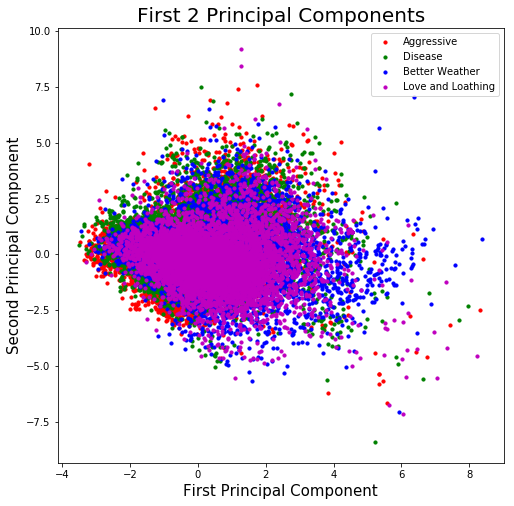

```python
# Define colors
colors = ['r', 'g', 'b', 'm']

# Make plot
fig = plt.figure(figsize = (8,8))
ax = fig.add_subplot(1,1,1)
ax.set_xlabel('First Principal Component', fontsize = 15)
ax.set_ylabel('Second Principal Component', fontsize = 15)
ax.set_title('First 2 Principal Components', fontsize = 20)
for album, color in zip(albumnames,colors):
    indicesToKeep = final['album'] == album
    ax.scatter(final.loc[indicesToKeep, 0]
               , final.loc[indicesToKeep, 1]
               , c = color
               , s = 10)
ax.legend(albumnames)
plt.show()
```

In the graph above, the red and green dots represent the sounds in the albums by the first artist, and the blue and magenta dots represent the sounds in the albums by the second artist. The graph is not too informative, but we can see that there are some outer areas that are mostly unique to one artist or album.

Now I will cluster all of the sounds from all of the albums into 70 clusters.

```python
# Cluster all the sounds from all the albums into 70 clusters
kmeans = KMeans(n_clusters=70, random_state=0)
labels = kmeans.fit_predict(x)
```

```python
# Table of the number of sounds in each group by artist
pandas.crosstab(final['artist'], labels)
```

| col_0 artist | 0 | 1 | 2 | 3 | 4 | 5 | 6 | 7 | 8 | 9 | ... | 60 | 61 | 62 | 63 | 64 | 65 | 66 | 67 | 68 | 69 |
| --- | --- | --- | --- | --- | --- | --- | --- | --- | --- | --- | --- | --- | --- | --- | --- | --- | --- | --- | --- | --- | --- |
| Beartooth | 9 | 453 | 579 | 462 | 304 | 94 | 165 | 516 | 20 | 143 | ... | 718 | 18 | 78 | 898 | 204 | 40 | 582 | 40 | 275 | 445 |
| With Confidence | 91 | 415 | 86 | 401 | 94 | 264 | 149 | 440 | 117 | 240 | ... | 193 | 54 | 80 | 67 | 76 | 64 | 200 | 121 | 75 | 177 |

2 rows × 70 columns

```python
# Table of the number of sounds in each group by album
pandas.crosstab(final['album'], labels).loc[albumnames]
```

| col_0 album | 0 | 1 | 2 | 3 | 4 | 5 | 6 | 7 | 8 | 9 | ... | 60 | 61 | 62 | 63 | 64 | 65 | 66 | 67 | 68 | 69 |
| --- | --- | --- | --- | --- | --- | --- | --- | --- | --- | --- | --- | --- | --- | --- | --- | --- | --- | --- | --- | --- | --- |
| Aggressive | 1 | 225 | 289 | 291 | 97 | 65 | 84 | 371 | 3 | 77 | ... | 603 | 10 | 20 | 138 | 118 | 25 | 230 | 13 | 103 | 327 |
| Disease | 8 | 228 | 290 | 171 | 207 | 29 | 81 | 145 | 17 | 66 | ... | 115 | 8 | 58 | 760 | 86 | 15 | 352 | 27 | 172 | 118 |
| Better Weather | 84 | 260 | 27 | 213 | 46 | 105 | 36 | 286 | 106 | 49 | ... | 54 | 51 | 48 | 5 | 19 | 31 | 70 | 47 | 24 | 82 |
| Love and Loathing | 7 | 155 | 59 | 188 | 48 | 159 | 113 | 154 | 11 | 191 | ... | 139 | 3 | 32 | 62 | 57 | 33 | 130 | 74 | 51 | 95 |

4 rows × 70 columns

In the above two tables, we can see that some groups have significantly more sounds from one artist or album. For example, group 0 is mostly made up of sounds from the second artist, and most of those sounds are from the first album of the second artist.

I can now calculate the proportion of each song's sounds that are in each group and use that to cluster the songs together.

```python
# Calculate the proportion of each song's sounds that are in each group
soundtable = pandas.crosstab(final['track'], labels, normalize='index').reset_index()
sounddata = pandas.DataFrame()
for i in albums:
    sounddata = sounddata.append(i, ignore_index=True)
sounddata = sounddata.merge(soundtable)

# Standardize the data
y = sounddata.iloc[:, 4:].values
y = StandardScaler().fit_transform(y)

# Unnecessary, but perform PCA for visualization
pca2 = PCA()
pca3 = pca2.fit_transform(y)
principal2 = pandas.DataFrame(data=pca3)
final2 = pandas.concat([principal2, sounddata.iloc[:, 0:4]], axis = 1)
```

Again, it is not necessary to perform principal component analysis before the second k-means clustering step, but graphing the first two principal components shows how effective the first k-means clustering step was in grouping similar sounds.

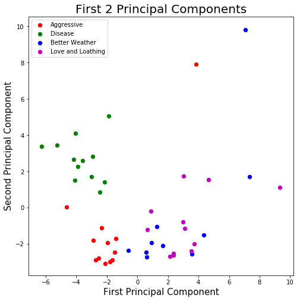

```python
# Make plot
fig = plt.figure(figsize = (8,8))
ax = fig.add_subplot(1,1,1)
ax.set_xlabel('First Principal Component', fontsize = 15)
ax.set_ylabel('Second Principal Component', fontsize = 15)
ax.set_title('First 2 Principal Components', fontsize = 20)
for album, color in zip(albumnames,colors):
    indicesToKeep = final2['album'] == album
    ax.scatter(final2.loc[indicesToKeep, 0]
               , final2.loc[indicesToKeep, 1]
               , c = color
               , s = 40)
ax.legend(albumnames)
plt.show()
```

By only looking at the first two principal components, we can already see there is a clear separation between the sounds of the tracks of the two different artists (red and green versus blue and magenta). Additionally, it is very interesting to see that there is a clear separation between the two albums of the first artist, indicating that the two albums by that artist have significantly different sounds. We can also see two outlier points in the top right corner of the graph; one point is from each artist.

Now I can perform the final k-means clustering step to see how well the artists' tracks separated.

```python
# Cluster the tracks into 2 groups
kmeans2 = KMeans(n_clusters=2, random_state=0)
labels2 = kmeans2.fit_predict(y)
pandas.crosstab(labels2, final2['artist'])
```

| artist row_0 | Beartooth | With Confidence |
| --- | --- | --- |
| 0 | 23 | 0 |
| 1 | 1 | 22 |

As expected from the graph, the artists separated very well. 23 out of 24 of the first artist's tracks were grouped together, and all 22 of the second artist's tracks were grouped together. Surely, the 1 track that was incorrectly grouped is the outlier from the first album of the first artist. The overall accuracy here is 97.8%, which is quite good.

```python
# Cluster the tracks into 4 groups
kmeans2 = KMeans(n_clusters=4, random_state=0)
labels2 = kmeans2.fit_predict(y)
table1 = pandas.crosstab(labels2, final2['album'])
table1.loc[:, albumnames]
```

| album row_0 | Aggressive | Disease | Better Weather | Love and Loathing |
| --- | --- | --- | --- | --- |
| 0 | 0 | 0 | 3 | 12 |
| 1 | 0 | 12 | 0 | 0 |
| 2 | 11 | 0 | 6 | 0 |
| 3 | 1 | 0 | 1 | 0 |

Splitting the tracks into 4 groups shows how outlier tracks can cause problems. Group 0 is composed of all 12 songs from the second album of the second artist as well as 3 songs from the first album of the same artist, which is acceptable. Group 1 is purely composed of all 12 songs of the second album of the first artist. Group 3 is only composed of the 2 outlier tracks; this causes group 2 to be composed of several tracks from 2 different albums.

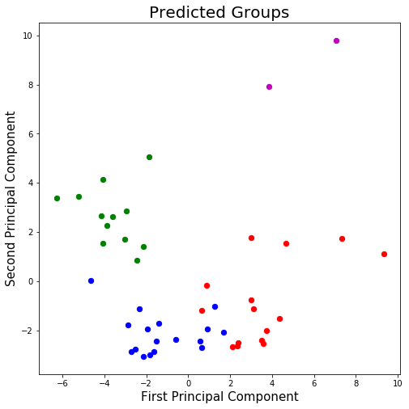

```python
# Plot predicted groups
fig = plt.figure(figsize = (8,8))
ax = fig.add_subplot(1,1,1)
ax.set_xlabel('First Principal Component', fontsize = 15)
ax.set_ylabel('Second Principal Component', fontsize = 15)
ax.set_title('Predicted Groups', fontsize = 20)
for label, color in zip(range(len(albums)),colors):
    indicesToKeep = labels2 == label
    ax.scatter(final2.loc[indicesToKeep, 0]
               , final2.loc[indicesToKeep, 1]
               , c = color
               , s = 40)
plt.show()
```

The plot above shows the predicted groups. Note that the colors have no particular meaning other than to differentiate the groups.

I can overcome the problem of outlier tracks by requiring each group to have a minimum of 5 tracks or otherwise remove the tracks in the small group and re-cluster. However, it is worth asking the question: Is it good or bad to identify outlier tracks by grouping them in their own group?

```python
# Recluster without outliers if there are less than 5 tracks in a group
if min(table1.sum(1)) < 5:
    labels3 = kmeans2.fit_predict(y[labels2 != table1.sum(1).idxmin()])
    table2 = pandas.crosstab(labels3, final2['album'][labels2 != table1.sum(1).idxmin()])
table2.loc[:, albumnames]
```

| album row_0 | Aggressive | Disease | Better Weather | Love and Loathing |
| --- | --- | --- | --- | --- |
| 0 | 1 | 12 | 0 | 0 |
| 1 | 0 | 0 | 2 | 12 |
| 2 | 10 | 0 | 0 | 0 |
| 3 | 0 | 0 | 7 | 0 |

After removing the 2 outlier tracks, I observed 93.2% accuracy in grouping the remaining tracks by album, and 100% accuracy in grouping the remaining tracks by artist.

```python
# View outlier tracks
final2.iloc[labels2 == table1.sum(1).idxmin(), -3:]
```

|  | track | album | artist |
| --- | --- | --- | --- |
| 11 | King of Anything | Aggressive | Beartooth |
| 30 | Long Night | Better Weather | With Confidence |

Further investigation shows that the two outlier tracks are each the slowest/softest song on their respective album.

## Part 2: Six Albums from Different Artists

The dataset includes six albums by six different rock bands.

```python
# Define the albums
albumnames = ['Disease', 'Love and Loathing', 'Living Proof', 'You Are OK', 'Sunnyland', 'Skinny Dipping']
albumids = ['1EFr8cW4waL1ASHS1RdmhF', '07aGx2IErugtk4d7clL03j', '1Qb73C8hC76e3R8udyit5I',
            '0DRUOQBsax8QLUVctbEIAT', '55sUM2N9C0vUHeqc1C6xEZ', '4xtHySb6XaNo8SLRgfpUSu']
```

```python
# Load the track ids
albums = albumids
for i, j in enumerate(albumids):
    albums[i] = pandas.read_csv('trackids/' + j + '.csv')

# Load the audio analyses
data = pandas.DataFrame()
for i in albums:
    for j, k in enumerate(i['trackid']):
        trackdata = pandas.read_csv('analysis/' + k + '.csv')
        trackdata['track'] = i['track'][j]
        trackdata['album'] = i['album'][j]
        trackdata['artist'] = i['artist'][j]
        data = data.append(trackdata, ignore_index=True)

# Standardize the data
x = data.iloc[:, 0:12].values
x = StandardScaler().fit_transform(x)

# Unnecessary, but perform PCA for visualization
pca = PCA()
pca1 = pca.fit_transform(x)
principal = pandas.DataFrame(data=pca1)
final = pandas.concat([principal, data.iloc[:, 12:]], axis = 1)
```

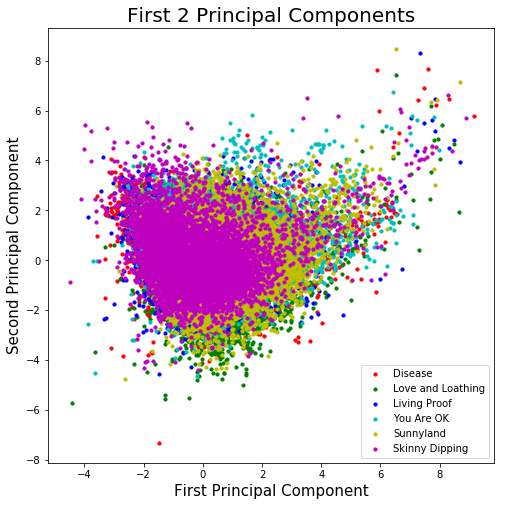

```python
# Define colors
colors = ['r', 'g', 'b', 'c', 'y', 'm']

# Make plot
fig = plt.figure(figsize = (8,8))
ax = fig.add_subplot(1,1,1)
ax.set_xlabel('First Principal Component', fontsize = 15)
ax.set_ylabel('Second Principal Component', fontsize = 15)
ax.set_title('First 2 Principal Components', fontsize = 20)
for album, color in zip(albumnames,colors):
    indicesToKeep = final['album'] == album
    ax.scatter(final.loc[indicesToKeep, 0]
               , final.loc[indicesToKeep, 1]
               , c = color
               , s = 10)
ax.legend(albumnames)
plt.show()
```

```python
# Cluster all the sounds from all the albums into 70 clusters
kmeans = KMeans(n_clusters=70, random_state=0)
labels = kmeans.fit_predict(x)
```

```python
# Table of the number of sounds in each group by album
pandas.crosstab(final['album'], labels).loc[albumnames]
```

| col_0 album | 0 | 1 | 2 | 3 | 4 | 5 | 6 | 7 | 8 | 9 | ... | 60 | 61 | 62 | 63 | 64 | 65 | 66 | 67 | 68 | 69 |
| --- | --- | --- | --- | --- | --- | --- | --- | --- | --- | --- | --- | --- | --- | --- | --- | --- | --- | --- | --- | --- | --- |
| Disease | 216 | 139 | 41 | 13 | 512 | 45 | 176 | 15 | 158 | 502 | ... | 95 | 240 | 51 | 385 | 9 | 1 | 127 | 205 | 233 | 10 |
| Love and Loathing | 17 | 176 | 24 | 41 | 67 | 266 | 203 | 30 | 124 | 72 | ... | 204 | 109 | 539 | 67 | 7 | 6 | 39 | 53 | 531 | 54 |
| Living Proof | 181 | 227 | 142 | 70 | 235 | 146 | 133 | 83 | 477 | 264 | ... | 156 | 337 | 145 | 164 | 5 | 12 | 53 | 70 | 149 | 31 |
| You Are OK | 259 | 129 | 327 | 441 | 179 | 119 | 58 | 124 | 181 | 156 | ... | 236 | 407 | 110 | 105 | 9 | 110 | 179 | 24 | 127 | 107 |
| Sunnyland | 33 | 154 | 106 | 128 | 129 | 148 | 409 | 222 | 278 | 76 | ... | 218 | 115 | 141 | 108 | 5 | 74 | 100 | 33 | 239 | 75 |
| Skinny Dipping | 196 | 99 | 154 | 61 | 95 | 111 | 23 | 206 | 196 | 145 | ... | 234 | 182 | 48 | 161 | 4 | 12 | 103 | 92 | 132 | 21 |

6 rows × 70 columns

In the above table, we can see that some groups have significantly more sounds from one artist. For example, group 4 is mostly made up of sounds from the first artist.

I can now calculate the proportion of each song's sounds that are in each group and use that to cluster the songs together.

```python
# Calculate the proportion of each song's sounds that are in each group
soundtable = pandas.crosstab(final['track'], labels, normalize='index').reset_index()
sounddata = pandas.DataFrame()
for i in albums:
    sounddata = sounddata.append(i, ignore_index=True)
sounddata = sounddata.merge(soundtable)

# Standardize the data
y = sounddata.iloc[:, 4:].values
y = StandardScaler().fit_transform(y)

# Unnecessary, but perform PCA for visualization
pca2 = PCA()
pca3 = pca2.fit_transform(y)
principal2 = pandas.DataFrame(data=pca3)
final2 = pandas.concat([principal2, sounddata.iloc[:, 0:4]], axis = 1)
```

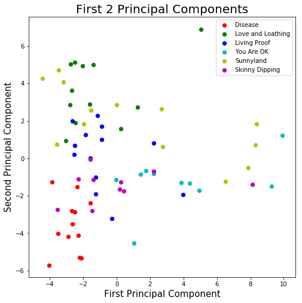

```python
# Make plot
fig = plt.figure(figsize = (8,8))
ax = fig.add_subplot(1,1,1)
ax.set_xlabel('First Principal Component', fontsize = 15)
ax.set_ylabel('Second Principal Component', fontsize = 15)
ax.set_title('First 2 Principal Components', fontsize = 20)
for album, color in zip(albumnames,colors):
    indicesToKeep = final2['album'] == album
    ax.scatter(final2.loc[indicesToKeep, 0]
               , final2.loc[indicesToKeep, 1]
               , c = color
               , s = 40)
ax.legend(albumnames)
plt.show()
```

By only looking at the first two principal components, we can see that some albums are clustering together better than others. The red, green, and blue dots separate fairly well, but the yellow dots span a large part of the graph.

Now I can perform the final k-means clustering step to see how well the albums' tracks separated.

```python
# Cluster the tracks into 6 groups
kmeans2 = KMeans(n_clusters=6, random_state=0)
labels2 = kmeans2.fit_predict(y)
table1 = pandas.crosstab(labels2, final2['album'])
table1.loc[:, albumnames]
```

| album row_0 | Disease | Love and Loathing | Living Proof | You Are OK | Sunnyland | Skinny Dipping |
| --- | --- | --- | --- | --- | --- | --- |
| 0 | 0 | 0 | 5 | 6 | 0 | 9 |
| 1 | 0 | 12 | 0 | 0 | 0 | 0 |
| 2 | 12 | 0 | 0 | 1 | 0 | 0 |
| 3 | 0 | 0 | 0 | 3 | 0 | 0 |
| 4 | 0 | 0 | 1 | 0 | 6 | 1 |
| 5 | 0 | 0 | 7 | 0 | 7 | 0 |

The first 2 albums separated from the others very well, but the last 4 albums did not. The last 4 artists are all playing at the same music festival together this summer, so it is reasonable to say they are closely related, but it is still disappointing that the clustering was not able to do a better job separating the albums. A machine learning method could likely do a better job, or this method could probably be improved with the improvement of the timbre vector.

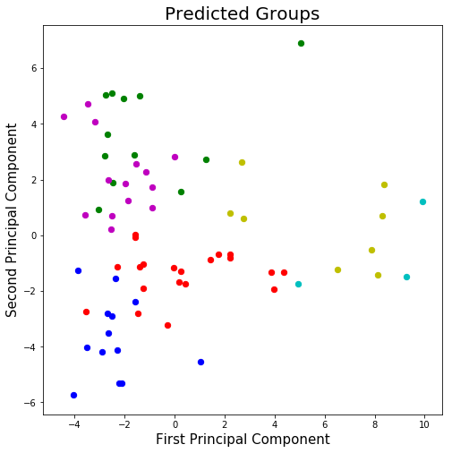

```python
# Plot predicted groups
fig = plt.figure(figsize = (8,8))
ax = fig.add_subplot(1,1,1)
ax.set_xlabel('First Principal Component', fontsize = 15)
ax.set_ylabel('Second Principal Component', fontsize = 15)
ax.set_title('Predicted Groups', fontsize = 20)
for label, color in zip(range(len(albums)),colors):
    indicesToKeep = labels2 == label
    ax.scatter(final2.loc[indicesToKeep, 0]
               , final2.loc[indicesToKeep, 1]
               , c = color
               , s = 40)
plt.show()
```

The plot above shows the predicted groups. Note that the colors have no particular meaning other than to differentiate the groups.

## Part 3: A Pop Punk Playlist and an Acoustic Punk Playlist

The dataset includes two playlists by Spotify: Pop Punk's Not Dead and Punk Unplugged.

```python
# Define the playlists
playlistnames = ['Pop Punk\'s Not Dead', 'Punk Unplugged']
playlistids = ['37i9dQZF1DX1ewVhAJ17m4', '37i9dQZF1DXcBkxDaAQX0a']
```

```python
# Load the track ids
playlists = playlistids
for i, j in enumerate(playlistids):
    playlists[i] = pandas.read_csv('trackids/' + j + '.csv')

# Load the audio analyses
data = pandas.DataFrame()
for i in playlists:
    for j, k in enumerate(i['trackid']):
        trackdata = pandas.read_csv('analysis/' + k + '.csv')
        trackdata['track'] = i['track'][j]
        trackdata['playlist'] = i['playlist'][j]
        trackdata['artist'] = i['artist'][j]
        data = data.append(trackdata, ignore_index=True)

# Standardize the data
x = data.iloc[:, 0:12].values
x = StandardScaler().fit_transform(x)

# Unnecessary, but perform PCA for visualization
pca = PCA()
pca1 = pca.fit_transform(x)
principal = pandas.DataFrame(data=pca1)
final = pandas.concat([principal, data.iloc[:, 12:]], axis = 1)
```

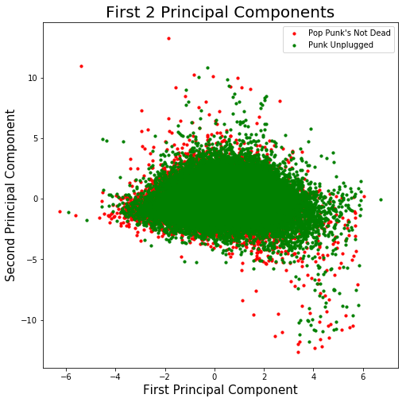

```python
# Define colors
colors = ['r', 'g']

# Make plot
fig = plt.figure(figsize = (8,8))
ax = fig.add_subplot(1,1,1)
ax.set_xlabel('First Principal Component', fontsize = 15)
ax.set_ylabel('Second Principal Component', fontsize = 15)
ax.set_title('First 2 Principal Components', fontsize = 20)
for playlist, color in zip(playlistnames,colors):
    indicesToKeep = final['playlist'] == playlist
    ax.scatter(final.loc[indicesToKeep, 0]
               , final.loc[indicesToKeep, 1]
               , c = color
               , s = 10)
ax.legend(playlistnames)
plt.show()
```

```python
# Cluster all the sounds from both playlists into 70 clusters
kmeans = KMeans(n_clusters=70, random_state=0)
labels = kmeans.fit_predict(x)
```

```python
# Table of the number of sounds in each group by playlist
pandas.crosstab(final['playlist'], labels).loc[playlistnames]
```

| col_0 playlist | 0 | 1 | 2 | 3 | 4 | 5 | 6 | 7 | 8 | 9 | ... | 60 | 61 | 62 | 63 | 64 | 65 | 66 | 67 | 68 | 69 |
| --- | --- | --- | --- | --- | --- | --- | --- | --- | --- | --- | --- | --- | --- | --- | --- | --- | --- | --- | --- | --- | --- |
| Pop Punk's Not Dead | 169 | 764 | 59 | 213 | 1429 | 1061 | 1445 | 475 | 682 | 291 | ... | 387 | 279 | 709 | 229 | 111 | 471 | 201 | 1487 | 361 | 206 |
| Punk Unplugged | 277 | 695 | 788 | 42 | 264 | 343 | 292 | 639 | 459 | 1009 | ... | 615 | 752 | 441 | 415 | 525 | 412 | 632 | 320 | 790 | 918 |

2 rows × 70 columns

In the above table, we can see that some groups have significantly more sounds from one playlist. For example, group 4 has significantly more sounds from the first playlist.

I can now calculate the proportion of each song's sounds that are in each group and use that to cluster the songs together.

```python
# Calculate the proportion of each song's sounds that are in each group
soundtable = pandas.crosstab(final['track'], labels, normalize='index').reset_index()
sounddata = pandas.DataFrame()
for i in playlists:
    sounddata = sounddata.append(i, ignore_index=True)
sounddata = sounddata.merge(soundtable)

# Standardize the data
y = sounddata.iloc[:, 4:].values
y = StandardScaler().fit_transform(y)

# Unnecessary, but perform PCA for visualization
pca2 = PCA()
pca3 = pca2.fit_transform(y)
principal2 = pandas.DataFrame(data=pca3)
final2 = pandas.concat([principal2, sounddata.iloc[:, 0:4]], axis = 1)
```

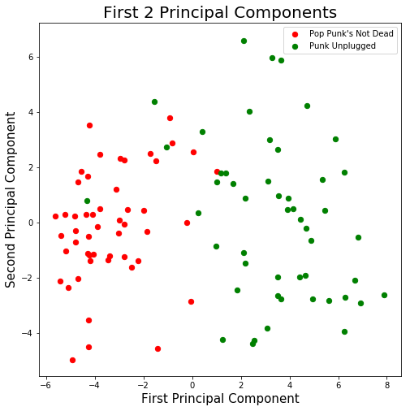

```python
# Make plot
fig = plt.figure(figsize = (8,8))
ax = fig.add_subplot(1,1,1)
ax.set_xlabel('First Principal Component', fontsize = 15)
ax.set_ylabel('Second Principal Component', fontsize = 15)
ax.set_title('First 2 Principal Components', fontsize = 20)
for playlist, color in zip(playlistnames,colors):
    indicesToKeep = final2['playlist'] == playlist
    ax.scatter(final2.loc[indicesToKeep, 0]
               , final2.loc[indicesToKeep, 1]
               , c = color
               , s = 40)
ax.legend(playlistnames)
plt.show()
```

By only looking at the first two principal components, we can already see there is a clear separation between the sounds of the tracks of the two different playlists.

Now I can perform the final k-means clustering step to see how well the playlists' tracks separated.

```python
# Cluster the tracks into 2 groups
kmeans2 = KMeans(n_clusters=2, random_state=0)
labels2 = kmeans2.fit_predict(y)
table1 = pandas.crosstab(labels2, final2['playlist'])
table1.loc[:, playlistnames]
```

| playlist row_0 | Pop Punk's Not Dead | Punk Unplugged |
| --- | --- | --- |
| 0 | 49 | 3 |
| 1 | 1 | 47 |

96% of the tracks were grouped together properly, which is quite good.

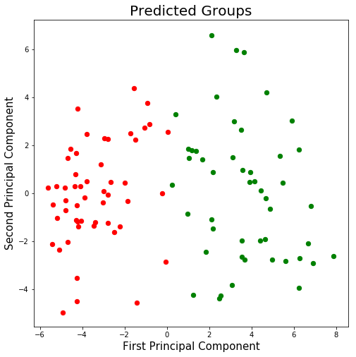

```python
# Plot predicted groups
fig = plt.figure(figsize = (8,8))
ax = fig.add_subplot(1,1,1)
ax.set_xlabel('First Principal Component', fontsize = 15)
ax.set_ylabel('Second Principal Component', fontsize = 15)
ax.set_title('Predicted Groups', fontsize = 20)
for label, color in zip(range(len(playlists)),colors):
    indicesToKeep = labels2 == label
    ax.scatter(final2.loc[indicesToKeep, 0]
               , final2.loc[indicesToKeep, 1]
               , c = color
               , s = 40)
plt.show()
```

The plot above shows the predicted groups. Note that the colors have no particular meaning other than to differentiate the groups.

## Part 4: A Pop Punk Playlist and a Country Playlist

The dataset includes two playlists by Spotify: Pop Punk's Not Dead and Hot Country.

```python
# Define the playlists
playlistnames = ['Pop Punk\'s Not Dead', 'Hot Country']
playlistids = ['37i9dQZF1DX1ewVhAJ17m4', '37i9dQZF1DX1lVhptIYRda']
```

```python
# Load the track ids
playlists = playlistids
for i, j in enumerate(playlistids):
    playlists[i] = pandas.read_csv('trackids/' + j + '.csv')

# Load the audio analyses
data = pandas.DataFrame()
for i in playlists:
    for j, k in enumerate(i['trackid']):
        trackdata = pandas.read_csv('analysis/' + k + '.csv')
        trackdata['track'] = i['track'][j]
        trackdata['playlist'] = i['playlist'][j]
        trackdata['artist'] = i['artist'][j]
        data = data.append(trackdata, ignore_index=True)

# Standardize the data
x = data.iloc[:, 0:12].values
x = StandardScaler().fit_transform(x)

# Unnecessary, but perform PCA for visualization
pca = PCA()
pca1 = pca.fit_transform(x)
principal = pandas.DataFrame(data=pca1)
final = pandas.concat([principal, data.iloc[:, 12:]], axis = 1)
```

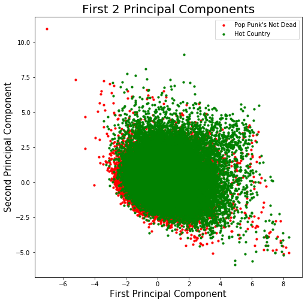

```python
# Define colors
colors = ['r', 'g']

# Make plot
fig = plt.figure(figsize = (8,8))
ax = fig.add_subplot(1,1,1)
ax.set_xlabel('First Principal Component', fontsize = 15)
ax.set_ylabel('Second Principal Component', fontsize = 15)
ax.set_title('First 2 Principal Components', fontsize = 20)
for playlist, color in zip(playlistnames,colors):
    indicesToKeep = final['playlist'] == playlist
    ax.scatter(final.loc[indicesToKeep, 0]
               , final.loc[indicesToKeep, 1]
               , c = color
               , s = 10)
ax.legend(playlistnames)
plt.show()
```

```python
# Cluster all the sounds from both playlists into 70 clusters
kmeans = KMeans(n_clusters=70, random_state=0)
labels = kmeans.fit_predict(x)
```

```python
# Table of the number of sounds in each group by playlist
pandas.crosstab(final['playlist'], labels).loc[playlistnames]
```

| col_0 playlist | 0 | 1 | 2 | 3 | 4 | 5 | 6 | 7 | 8 | 9 | ... | 60 | 61 | 62 | 63 | 64 | 65 | 66 | 67 | 68 | 69 |
| --- | --- | --- | --- | --- | --- | --- | --- | --- | --- | --- | --- | --- | --- | --- | --- | --- | --- | --- | --- | --- | --- |
| Pop Punk's Not Dead | 275 | 1432 | 510 | 82 | 419 | 343 | 809 | 172 | 815 | 147 | ... | 73 | 115 | 226 | 288 | 436 | 1116 | 593 | 110 | 387 | 61 |
| Hot Country | 601 | 593 | 575 | 439 | 529 | 560 | 616 | 408 | 575 | 786 | ... | 350 | 504 | 702 | 471 | 380 | 318 | 1222 | 256 | 423 | 376 |

2 rows × 70 columns

In the above table, we can see that some groups have significantly more sounds from one playlist. For example, group 65 has significantly more sounds from the first playlist.

I can now calculate the proportion of each song's sounds that are in each group and use that to cluster the songs together.

```python
# Calculate the proportion of each song's sounds that are in each group
soundtable = pandas.crosstab(final['track'], labels, normalize='index').reset_index()
sounddata = pandas.DataFrame()
for i in playlists:
    sounddata = sounddata.append(i, ignore_index=True)
sounddata = sounddata.merge(soundtable)

# Standardize the data
y = sounddata.iloc[:, 4:].values
y = StandardScaler().fit_transform(y)

# Unnecessary, but perform PCA for visualization
pca2 = PCA()
pca3 = pca2.fit_transform(y)
principal2 = pandas.DataFrame(data=pca3)
final2 = pandas.concat([principal2, sounddata.iloc[:, 0:4]], axis = 1)
```

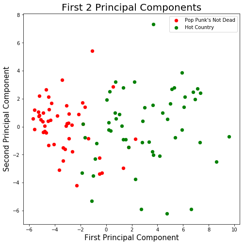

```python
# Make plot
fig = plt.figure(figsize = (8,8))
ax = fig.add_subplot(1,1,1)
ax.set_xlabel('First Principal Component', fontsize = 15)
ax.set_ylabel('Second Principal Component', fontsize = 15)
ax.set_title('First 2 Principal Components', fontsize = 20)
for playlist, color in zip(playlistnames,colors):
    indicesToKeep = final2['playlist'] == playlist
    ax.scatter(final2.loc[indicesToKeep, 0]
               , final2.loc[indicesToKeep, 1]
               , c = color
               , s = 40)
ax.legend(playlistnames)
plt.show()
```

By only looking at the first two principal components, we can already see there is pretty good separation between the sounds of the tracks of the two different playlists.

Now I can perform the final k-means clustering step to see how well the playlists' tracks separated.

```python
# Cluster the tracks into 2 groups
kmeans2 = KMeans(n_clusters=2, random_state=0)
labels2 = kmeans2.fit_predict(y)
table1 = pandas.crosstab(labels2, final2['playlist'])
table1.loc[:, playlistnames]
```

| playlist row_0 | Pop Punk's Not Dead | Hot Country |
| --- | --- | --- |
| 0 | 47 | 12 |
| 1 | 3 | 40 |

85.3% of the tracks were grouped together properly. Most of the pop punk tracks were grouped together properly, but 12 of the country tracks were included in the pop punk group.

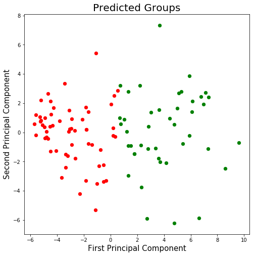

```python
# Plot predicted groups
fig = plt.figure(figsize = (8,8))
ax = fig.add_subplot(1,1,1)
ax.set_xlabel('First Principal Component', fontsize = 15)
ax.set_ylabel('Second Principal Component', fontsize = 15)
ax.set_title('Predicted Groups', fontsize = 20)
for label, color in zip(range(len(playlists)),colors):
    indicesToKeep = labels2 == label
    ax.scatter(final2.loc[indicesToKeep, 0]
               , final2.loc[indicesToKeep, 1]
               , c = color
               , s = 40)
plt.show()
```

The plot above shows the predicted groups. Note that the colors have no particular meaning other than to differentiate the groups.

## Part 5: An Acoustic Punk Playlist and a Country Playlist

The dataset includes two playlists by Spotify: Punk Unplugged and Hot Country.

```python
# Define the playlists
playlistnames = ['Punk Unplugged', 'Hot Country']
playlistids = ['37i9dQZF1DXcBkxDaAQX0a', '37i9dQZF1DX1lVhptIYRda']
```

```python
# Load the track ids
playlists = playlistids
for i, j in enumerate(playlistids):
    playlists[i] = pandas.read_csv('trackids/' + j + '.csv')

# Load the audio analyses
data = pandas.DataFrame()
for i in playlists:
    for j, k in enumerate(i['trackid']):
        trackdata = pandas.read_csv('analysis/' + k + '.csv')
        trackdata['track'] = i['track'][j]
        trackdata['playlist'] = i['playlist'][j]
        trackdata['artist'] = i['artist'][j]
        data = data.append(trackdata, ignore_index=True)

# Standardize the data
x = data.iloc[:, 0:12].values
x = StandardScaler().fit_transform(x)

# Unnecessary, but perform PCA for visualization
pca = PCA()
pca1 = pca.fit_transform(x)
principal = pandas.DataFrame(data=pca1)
final = pandas.concat([principal, data.iloc[:, 12:]], axis = 1)
```

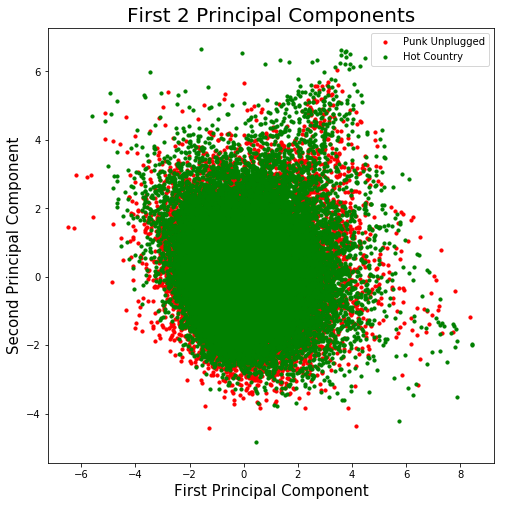

```python
# Define colors
colors = ['r', 'g']

# Make plot
fig = plt.figure(figsize = (8,8))
ax = fig.add_subplot(1,1,1)
ax.set_xlabel('First Principal Component', fontsize = 15)
ax.set_ylabel('Second Principal Component', fontsize = 15)
ax.set_title('First 2 Principal Components', fontsize = 20)
for playlist, color in zip(playlistnames,colors):
    indicesToKeep = final['playlist'] == playlist
    ax.scatter(final.loc[indicesToKeep, 0]
               , final.loc[indicesToKeep, 1]
               , c = color
               , s = 10)
ax.legend(playlistnames)
plt.show()
```

```python
# Cluster all the sounds from both playlists into 70 clusters
kmeans = KMeans(n_clusters=70, random_state=0)
labels = kmeans.fit_predict(x)
```

```python
# Table of the number of sounds in each group by playlist
pandas.crosstab(final['playlist'], labels).loc[playlistnames]
```

| col_0 playlist | 0 | 1 | 2 | 3 | 4 | 5 | 6 | 7 | 8 | 9 | ... | 60 | 61 | 62 | 63 | 64 | 65 | 66 | 67 | 68 | 69 |
| --- | --- | --- | --- | --- | --- | --- | --- | --- | --- | --- | --- | --- | --- | --- | --- | --- | --- | --- | --- | --- | --- |
| Punk Unplugged | 194 | 588 | 297 | 578 | 634 | 619 | 287 | 862 | 278 | 397 | ... | 739 | 676 | 600 | 617 | 574 | 608 | 373 | 691 | 521 | 823 |
| Hot Country | 711 | 944 | 293 | 1166 | 501 | 606 | 236 | 597 | 347 | 1125 | ... | 657 | 796 | 680 | 459 | 392 | 544 | 521 | 555 | 464 | 486 |

2 rows × 70 columns

In the above table, we can see that some groups have significantly more sounds from one playlist. For example, group 9 has significantly more sounds from the second playlist.

I can now calculate the proportion of each song's sounds that are in each group and use that to cluster the songs together.

```python
# Calculate the proportion of each song's sounds that are in each group
soundtable = pandas.crosstab(final['track'], labels, normalize='index').reset_index()
sounddata = pandas.DataFrame()
for i in playlists:
    sounddata = sounddata.append(i, ignore_index=True)
sounddata = sounddata.merge(soundtable)

# Standardize the data
y = sounddata.iloc[:, 4:].values
y = StandardScaler().fit_transform(y)

# Unnecessary, but perform PCA for visualization
pca2 = PCA()
pca3 = pca2.fit_transform(y)
principal2 = pandas.DataFrame(data=pca3)
final2 = pandas.concat([principal2, sounddata.iloc[:, 0:4]], axis = 1)
```

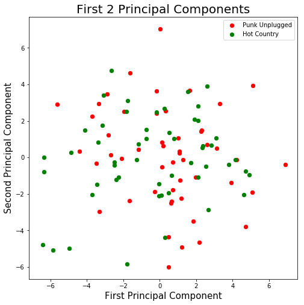

```python
# Make plot
fig = plt.figure(figsize = (8,8))
ax = fig.add_subplot(1,1,1)
ax.set_xlabel('First Principal Component', fontsize = 15)
ax.set_ylabel('Second Principal Component', fontsize = 15)
ax.set_title('First 2 Principal Components', fontsize = 20)
for playlist, color in zip(playlistnames,colors):
    indicesToKeep = final2['playlist'] == playlist
    ax.scatter(final2.loc[indicesToKeep, 0]
               , final2.loc[indicesToKeep, 1]
               , c = color
               , s = 40)
ax.legend(playlistnames)
plt.show()
```

By looking at the first two principal components, there is no clear separation between the sounds of the tracks of the two different playlists.

Now I can perform the final k-means clustering step to see how well the playlists' tracks separated.

```python
# Cluster the tracks into 2 groups
kmeans2 = KMeans(n_clusters=2, random_state=0)
labels2 = kmeans2.fit_predict(y)
table1 = pandas.crosstab(labels2, final2['playlist'])
table1.loc[:, playlistnames]
```

| playlist row_0 | Punk Unplugged | Hot Country |
| --- | --- | --- |
| 0 | 14 | 24 |
| 1 | 36 | 28 |

58.8% of the tracks were grouped together properly. This is not significantly better than random guessing. Unfortunately, this clustering method did not work well in separating 2 very different playlists.

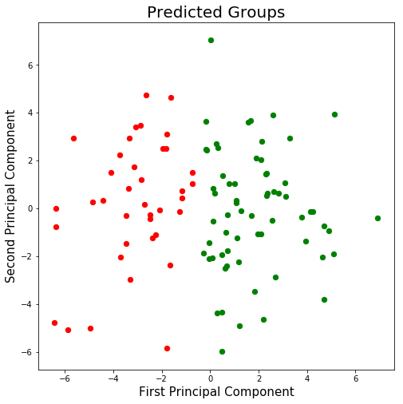

```python
# Plot predicted groups
fig = plt.figure(figsize = (8,8))
ax = fig.add_subplot(1,1,1)
ax.set_xlabel('First Principal Component', fontsize = 15)
ax.set_ylabel('Second Principal Component', fontsize = 15)
ax.set_title('Predicted Groups', fontsize = 20)
for label, color in zip(range(len(playlists)),colors):
    indicesToKeep = labels2 == label
    ax.scatter(final2.loc[indicesToKeep, 0]
               , final2.loc[indicesToKeep, 1]
               , c = color
               , s = 40)
plt.show()
```

The plot above shows the predicted groups. Note that the colors have no particular meaning other than to differentiate the groups.

# Final Thoughts

This two-part k-means clustering method worked pretty well in separating some artists, albums, and playlists, but it failed at sufficiently separating others. This method generally performs better than an alternative method where the first step is to take the column averages for the timbre vectors for each song and then cluster the column averages, but this method is much more computationally expensive than the alternative method. I think a machine learning algorithm could do a better job clustering tracks.